# In Class Components - Data Containers

## Examples

This in-class file is used for demonstrating individual examples related to this topic and is kept as a persistent record of examples provided during lectures.

## The Data

- The *iris* data set (that comes with R) that describes the sepal and pedal sizes on three species of *Iris*. This is a classic data set found in a wide variety of data sets and is a great example of having several sample measurements on several individuals in different groups.

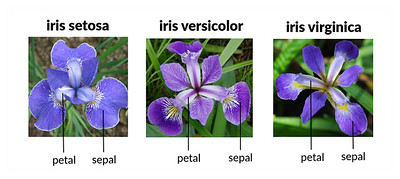

  Figure 1: Measurements of sepal and pedal lengths and width for three species of iris.

```r
url <- "https://raw.githubusercontent.com/DyerlabTeaching/Data-Containers/main/data/arapat.csv"
```

[output not shown]

## Vectors

A vector is a list of elements that **must** be the same class of variable.

```r
people <- c( "Rodney", "Sarah", "Elizabeth", "Colin" )
people
```

```
[1] "Rodney"    "Sarah"     "Elizabeth" "Colin"
```

```r
person <- "Bob"
person
```

```
[1] "Bob"
```

```r
myFavoriteLetters <- LETTERS[1:26]
myFavoriteLetters
```

```
 [1] "A" "B" "C" "D" "E" "F" "G" "H" "I" "J" "K" "L" "M" "N" "O" "P" "Q" "R" "S"
[20] "T" "U" "V" "W" "X" "Y" "Z"
```

Some numbers

```r
numbers <- c( 12, 434, 323, 3.2e3 )
numbers
```

```
[1]   12  434  323 3200
```

```r
numbers[2] <- 43
numbers
```

```
[1]   12   43  323 3200
```

```r
numbers[ 2:12 ]
```

```
 [1]   43  323 3200   NA   NA   NA   NA   NA   NA   NA   NA
```

```r
numbers[ 2:3] <- c(1,2)
numbers
```

```
[1]   12    1    2 3200
```

## Matrices

Matrices are a collection of data types in a 2- or 3-dimensional configuration, often used for mathematical modeling.

```r
matrix( 0, nrow=2, ncol=3) -> zeroMat
zeroMat
```

```
     [,1] [,2] [,3]
[1,]    0    0    0
[2,]    0    0    0
```

```r
matrix( c(1,2,3,4), nrow = 2 ) -> X

X
```

```
     [,1] [,2]
[1,]    1    3
[2,]    2    4
```

```r
1/X
```

```
     [,1]      [,2]
[1,]  1.0 0.3333333
[2,]  0.5 0.2500000
```

## Lists

Lists are a structure that allows you to have *named* variables. Elements may be of different class and sizes.

```r
cat <- list("Name" = "Colin", chonk = TRUE, legs = 4  )
cat[["Feeding"]] <- c("Morning", "Noon", "Night", "A little milk please")
cat$Snacks <- c("yes", "please")
cat
```

```
$Name
[1] "Colin"

$chonk
[1] TRUE

$legs
[1] 4

$Feeding
[1] "Morning"              "Noon"                 "Night"
[4] "A little milk please"

$Snacks
[1] "yes"    "please"
```

```r
cat$chonk
```

```
[1] TRUE
```

## Data Frames

A `data.frame` is a dense data container similar to that of a spreadsheet where each column has data of the same type (e..g, Latitude, or Temperature) and each row represents a single record of measurements taken together (same time, same individual, etc.).

```r
library( tidyverse )

read_csv( url ) -> araptus
```